# Rmarkdown简介

李峰

2017年2月28日

# Rmarkdown简介

# 1. 标题

为了获得上面的 “`1. 标题`”， 在 Markdown 编辑器里输入：

```
# 1. 标题
```

“`#`” 后最好加个空格。除此之外，还有 5 级标题，依次有不同的字体大小，即

```
## 二级标题
### 三级标题
#### 四级标题
##### 五级标题
###### 六级标题
```

这样就有：

## 二级标题

### 三级标题

#### 四级标题

##### 五级标题

###### 六级标题

# 2. 加粗，斜体

最常用的强调方式，那就是 **加粗** 了，你得这样：

```
最常用的强调方式，那就是 **加粗** 了，你得这样：
```

通常我喜欢在 “`**加粗的部分**`” 旁边各加一个空格，当然你也可以不这样。 斜体则多用在于书名，比如：我正在看 *Mind in the Making: The Seven Essential Life Skills Every Child Needs*

```
斜体则多用在于书名，比如：我正在看过 *Mind in the Making: The Seven Essential Life Skills Every Child Needs*
```

但中文的斜体真的很丑，像：《*基于R的统计分析与数据挖掘*》

# 3. 层次

比如写个华创报告，你得

#### 第一章

也不难：

```
#### 第一章

1. 第一节
* 第二节(你不用敲 "2"，自动就有了）
    * 第一小节（推荐每层次缩进四个空格）
        * 小小节 1
        * 小小节 2
    * 第二小节
```

“`*`” 后面要加空格，这是必须的，除了 `*`，还可以使用 `+` 或者 `-`。

# 4. 链接，图片

你：我没听过 *岳云鹏*的相声  
我：你可以去死了！  
你：。。。  
我：我也没听过，但是，岳云鹏喜欢[*Jane Eyre*](https://book.douban.com/subject/1141406/) 这本书

[figure not shown]

Jane Eyre

```
你：我没听过 *岳云鹏*的相声
我：你可以去死了！
你：。。。
我：我也没听过，但是，岳云鹏喜欢[***Jane Eyre***](https://book.douban.com/subject/1141406/)这本书
![Jane Eyre](https://img5.doubanio.com/lpic/s5924326.jpg)
```

# 5. 引用

> Markdown is not LaTeX.

为了使用rmarkdown，也许你需要以下包:

> library(knitr)  
> library(rmarkdown)  
> library(rprojroot)  
> library(backports)  
> library(evaluate)

# 6. 代码块

一段 *代码块* 如下. 记住如何嵌套进R的代码，运行结果会显示在代码下面，运行后的结果会出现在文本里:

```r
1+1
```

```
## [1] 2
```

```r
.4-.7+.3 # 为什么结果不是零？!
```

```
## [1] 5.551115e-17
```

````
```r
1+1
```

```
## [1] 2
```

```r
.4-.7+.3 # 为什么结果不是零？!
```

```
## [1] 5.551115e-17
```
````

```r
strsplit('hello indented world', ' ')[[1]]
```

```
## [1] "hello"    "indented" "world"
```

或者以**引用**的形式出现：

> Here is a quote, followed by a code chunk:

> ```r
> x = 1:10
> rev(x^2)
> ```

> ```
> ##  [1] 100  81  64  49  36  25  16   9   4   1
> ```

也可以在文内出现程序运行结果，如pi的值是 3.1415927, 2倍的pi值是 6.2831853。

# 7. 画图

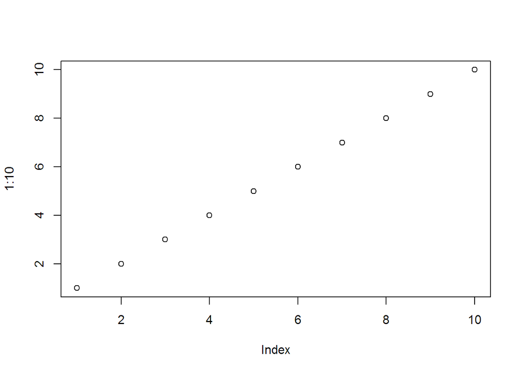

```r
plot(1:10)
```

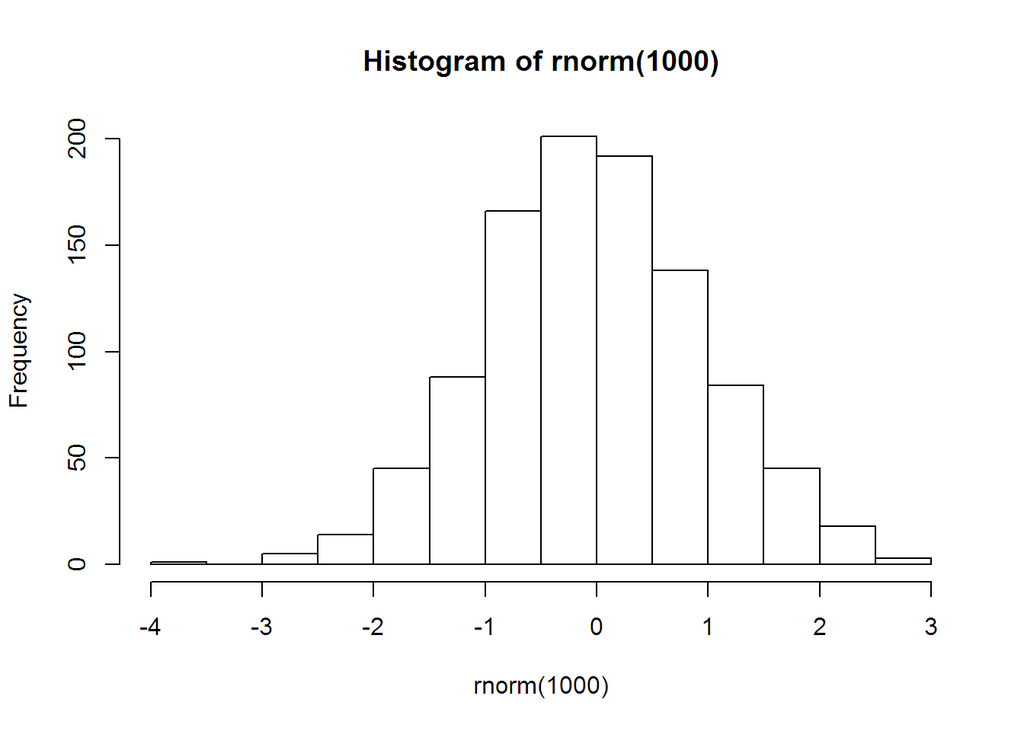

```r
hist(rnorm(1000))
```

# 8. 表格

| 姓名 | 学 号 | 专 业 | 联系方式 |
| --- | --- | --- | --- |
| 余子琳 | 100001 | 应用统计 | 382038080 |
| 谈一卓 | 100002 | 经济统计 | 329840480 |
| 王雨芯 | 100003 | 数理统计 | 289448984 |

# 9. 数学公式

Sigh. You cannot live without math equations. OK, here we go: $\alpha+\beta=\gamma$. Note this is not supported by native markdown. You probably want to try RStudio, or at least the R package **rmarkdown**.

# 10. 了解更多

了解更多*rmarkdown*，可以登陆`knitr`的开发者**谢益辉**的页面 [knitr website](http://yihui.name/knitr/).

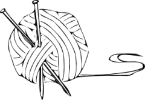

knitr logo